# Advanced Lane Finding Project

## 1. Overview

The goal of this project is to build a pipeline for lane findng and apply it to videos and images to check its performance. For further explanation, please have a look at `writeup.md`.

Before start building the pipeline for the lane finidng, we first load some libaries and images used throughout this project.

```python
### libraries
import numpy as np
import cv2
import matplotlib.pyplot as plt
import matplotlib.image as mpimg
from PIL import Image
import glob
from moviepy.editor import VideoFileClip
import pygame
%matplotlib inline
```

```python
### read names of the image files

# read images for camera calibration
cal_imgs = glob.glob('camera_cal/*.jpg')
# read test images (images of roads)
test_imgs = glob.glob('test_images/*.jpg')

# size of image is (1280,720) (and 3 channels for color)
img_size = cv2.imread(test_imgs[0]).shape[:2]
```

## 2. Camera Calibration and Distortion Correction

In this part we compute the camera calibration matrix and distortion coefficients for the camera used in this project. For this purpose we uses some chessboard images stored in the folder `camera_cal`. The calibration matrix is stored in **`mtx`** and the distortion coefficients are in **`dist`**.

```python
### obtain the camera calibration matrix and distortion coefficients

# prepare object points (= inner edges of the chessboard)
nx = 9 # the number of inside corners in x-direction
ny = 6 # the number of inside corners in y-direction

# list of object points and image points
objpoints= []
imgpoints = []

# objet points
objp = np.zeros((nx*ny,3), np.float32)
objp[:,:2] = np.mgrid[0:nx, 0:ny].T.reshape(-1, 2)

for fname in cal_imgs:

    img = cv2.imread(fname)
    img_size = (img.shape[1], img.shape[0])
    # convert to grayscale
    gray = cv2.cvtColor(img, cv2.COLOR_BGR2GRAY)
    # detect the corners of the chessboard
    ret, corners = cv2.findChessboardCorners(gray, (nx, ny), None)

    if ret ==True: # if corners are detected
        cv2.drawChessboardCorners(img, (nx,ny), corners, ret)
        # store image points and object points
        imgpoints.append(corners)
        objpoints.append(objp)

# camera calibration (mtx: calibration matrx, dist: distortion coefficients)
ret, mtx, dist, rvecs, tvecs = cv2.calibrateCamera(objpoints, imgpoints, img_size, None, None)
```

We can check how the camera calibration matrix and the distortion coefficients obtained correct the distortion of the chess board images in the folder `camera_cal`. Here is one example:

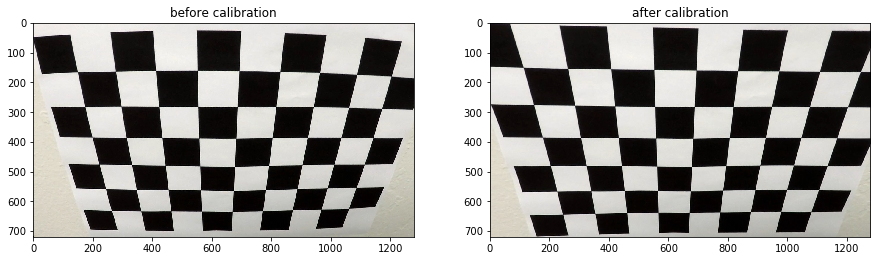

```python
### to see the undistorted images of a chess board
for fname in cal_imgs[11:12]:
    img = cv2.imread(fname)
    img = cv2.cvtColor(img, cv2.COLOR_BGR2RGB)
    undist = cv2.undistort(img, mtx, dist, None, mtx)

    fig=plt.figure(figsize=(15, 4))
    fig.add_subplot(1, 2, 1)
    plt.title('before calibration')
    plt.imshow(img)
    fig.add_subplot(1, 2, 2)
    plt.title('after calibration')
    plt.imshow(undist)
    # plt.savefig('output_images/calibration.png')
```

## 3. Pipeline for Lane Finding

In this part, we build the pipeline for lane finding.

### 3. 1. Distortion Correction

We first undistort images of roads in the folder `test_images` by using the camera calibration matrix and the distortion coefficients obtained above. Here is one example:

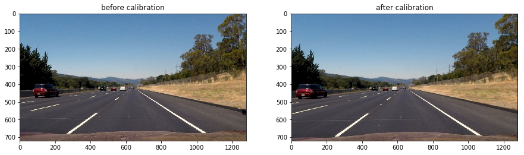

```python
### to see the undistorted version of test images
for fname in ["test_images/straight_lines2.jpg"]:
# for fname in test_imgs: # use this instead if one wants to apply for all the images
    img = cv2.imread(fname)
    img = cv2.cvtColor(img, cv2.COLOR_BGR2RGB)
    undist = cv2.undistort(img, mtx, dist, None, mtx)

    fig=plt.figure(figsize=(15, 4))
    fig.add_subplot(1, 2, 1)
    plt.title('before calibration')
    plt.imshow(img)
    fig.add_subplot(1, 2, 2)
    plt.title('after calibration')
    plt.imshow(undist)
    # plt.savefig('output_images/undistorted.png')
```

### 3.2. Gradient and Color Thresholding

In this part, we apply gradient thresholds and color thresholds with color transformations to generate a binary image used for the lane finding.

As a first step, we define some functions for computing binary images based on gradient threshold methods:

- `abs_sobel_thresh()`: compute the gradient in x/y-direction and apply to it a threshold to generate a binary image. (NOTE: This one is in the end not used for our pipeline.)
- `mag_thresh()`: compute the maginitude of the gradient and apply to it a threshold to generate a binary image.
- `dir_thresh()`: compute the direction of the gradient and apply to it a threshold to generate a binary image.

We also define a function for computing a binary image based on color threshold method followed by color transformation:

- `color_thresh()`: an image is converted (from `RGB`) to `HLS`, `HSV`, `LAB`, `LUV` or `YCrCb` color space, one of the three channel is chosen, and then a threshold is applied to this channel to generate a binary image.

The implementation of these functions are as follows:

```python
def abs_sobel_thresh(img, sobel_kernel=3, orient='x', thresh = (0, 255)):
    """
    apply Sobel operator in x or y direction
    and apply a threshold on the gradient in the chosen direction

    INPUT
    img: an array corresponding to a color image (RGB)
    sobel_kernel: kernel size of the Sobel operator
    orient: direction to act the Sobel operator with kernel size 3x3, 'x' or 'y'
    thresh: size 2 tuple storing lower and upper thresholds (take value in [0, 255])

    OUTPUT
    an array corresponding to a binary image (each entry is 1 or 0)

    """
    gray = cv2.cvtColor(img,cv2.COLOR_RGB2GRAY)
    if(orient == 'x'):
        sobel = cv2.Sobel(gray, cv2.CV_64F, 1, 0, ksize=sobel_kernel)
    elif(orient == 'y'):
        sobel = cv2.Sobel(gray, cv2.CV_64F, 0, 1, ksize=sobel_kernel)
    abs_sobel = np.absolute(sobel)
    # rescale to 8 bit
    scaled_sobel = (255*abs_sobel/np.max(abs_sobel)).astype(np.uint8)
    # generate a binary image
    binary_output = np.zeros_like(scaled_sobel)
    binary_output[(scaled_sobel >= thresh[0]) & (scaled_sobel <= thresh[1])] = 1

    return binary_output

def mag_thresh(img, sobel_kernel=3, thresh=(0, 255)):
    """
    apply Sobel operator in x and y directioon, compute the magnitude
    of the gradient and then apply a threshold on it

    INPUT
    img: an array corresponding to a color image (RGB)
    sobel_kernel: kernel size of the Sobel operator
    thresh: size 2 tuple storing lower and upper thresholds (take value in [0, 255])

    OUTPUT
    an array corresponding to a binary image (each entry is 1 or 0)

    """

    gray = cv2.cvtColor(img, cv2.COLOR_RGB2GRAY)
    # act the Sobel operator in x and y directions
    sobelx = cv2.Sobel(gray, cv2.CV_64F, 1, 0, ksize=sobel_kernel)
    sobely = cv2.Sobel(gray, cv2.CV_64F, 0, 1, ksize=sobel_kernel)
    # calculate the magnitude of the gradient
    gradmag = np.sqrt(sobelx**2 + sobely**2)
    # rescale to 8 bit
    scaled_gradmag = (255*gradmag/np.max(gradmag)).astype(np.uint8)
    # generate a binary image
    binary_output = np.zeros_like(scaled_gradmag)
    binary_output[(scaled_gradmag >= thresh[0]) & (scaled_gradmag <= thresh[1])] = 1

    return binary_output

def dir_thresh(img, sobel_kernel=3, thresh=(0, np.pi/2.0)):
    """
    apply Sobel operator in x and y directioon, compute the direction
    of the gradient and then apply a threshold on it

    INPUT
    img: an array corresponding to a color image (RGB)
    sobel_kernel: kernel size of the Sobel operator
    thresh: size 2 tuple storing lower and upper thresholds (take value in [0, 255])

    OUTPUT
    an array corresponding to a binary image (each entry is 1 or 0)

    """
    gray = cv2.cvtColor(img, cv2.COLOR_RGB2GRAY)
    # act the Sobel operator in x and y directions
    sobelx = cv2.Sobel(gray, cv2.CV_64F, 1, 0, ksize=sobel_kernel)
    sobely = cv2.Sobel(gray, cv2.CV_64F, 0, 1, ksize=sobel_kernel)
    abs_sobelx = np.absolute(sobelx)
    abs_sobely = np.absolute(sobely)
    # calculate the direction of the gradient
    direct = np.arctan2(abs_sobely, abs_sobelx)
    # generate a binary image
    binary_output = np.zeros_like(direct)
    binary_output[(direct >= thresh[0]) & (direct <= thresh[1])] = 1

    return binary_output

def color_thresh(img, cspace = 'HLS', channel = 2, thresh=(0, 255)):
    """
    this function converts an image from RGB to HLS (or HSV, YCrCb, LAB, LUV)
    and then apply a threshold on S channel for generating a binary image

    INPUT
    img: an array corresponding to a color image in RGB
    cspace: a color space to consider, 'HLS' or 'HSV'
    channel: color channel (in the case of 'HLS', 0/1/2 for 'H'/'L'/'S')
    thresh: size 2 tuple storing lower and upper thresholds (take value in [0, 255])

    OUTPUT
    an array corresponding to a binary image (each entry is 1 or 0)

    """

    # conver the image from RGB to HLS etc.
    if cspace == 'HLS':
        converted = cv2.cvtColor(img, cv2.COLOR_RGB2HLS)[:,:,channel]
    elif cspace == 'HSV':
        converted = cv2.cvtColor(img, cv2.COLOR_RGB2HSV)[:,:,channel]
    elif cspace == 'YCrCb':
        converted = cv2.cvtColor(img, cv2.COLOR_RGB2YCrCb)[:,:,channel]
    elif cspace == 'LAB':
        converted = cv2.cvtColor(img, cv2.COLOR_RGB2LAB)[:,:,channel]
    elif cspace == 'LUV':
        converted = cv2.cvtColor(img, cv2.COLOR_RGB2LUV)[:,:,channel]
    else: # in case unchanged
        converted = img[:,:,channel]
    # generate a binary image
    binary_output = np.zeros_like(converted)
    binary_output[(converted > thresh[0]) & (converted<= thresh[1])] = 1

    return binary_output
```

Now we combine these to build a function `pipeline_thresh` and generate a binary image used for lane finding. After various trials, we decided to combine as follows:

- For gradient thresholding, we combined `mag_thresh()` and `dir_thresh()` such that when a given pixel is detected by both of them, the pixel is regarded as being detected.
- For color thresholding,
  1. we first applied thresholds on S-channel of HLS and Y-channel of YCrCb and then we regard a given pixel as being deteced when the pixel is detected by thresholding on both of the channel,
  2. we also applied thresholds on L-channel of LAB,
  3. we also applied threshlds on B-channel of LAB. We then regard a given pixel as being detected when the pixel is detected at least one of the above three color thresholding.

Then, in the end, we combined the gradient thresholding and color thresholding such that a given pixel is regarded as being detected when either the gradient or color thresholding detects the pixel.

The implementation of the pipeline for the thresholding part is as follows:

```python
def pipeline_thresh(img, color = True):
    """
    This function combines gradient thresholds and color thresholds
    and returns a colored binary image

    INPUT:
    image: an array corresponding ot a color image in RGB or grayscale
    color: if True, the result of color/gradient thresholding is displayed in green/blue, if not,
            the results from the two thresholding are combined and a grayscale image is returned

    OUTPUT: image (depending on `color` input, color or grayscale)

    """
    # parameters for the thresholding
    mag_ker = 3
    mag_thr = (8, 10)
    # for direction threshold
    dir_ker = 31
    dir_thr = (0.92, 0.95)
    # # for Sobel x threshold
    # gradx_ker = 3
    # gradx_thr = (45, 255)
    # # for Sobel y threshold
    # grady_ker = 3
    # grady_thr = (45, 255)
    # for magnitude threshold

    # for HLS color threshold on S-channel
    cspace1 = 'HLS'
    channel1 = 2
    col_thresh1 = (90, 255)
    # for YCrCb color threshold on Y-channel
    cspace2 = 'YCrCb'
    channel2 = 0
    col_thresh2 = (120, 255)
    # for LAB color threshold on L-channel
    cspace3 = 'LAB'
    channel3 = 0
    col_thresh3 = (205, 255)
    # for LAB color threshold on B-channel
    cspace4 = 'LAB'
    channel4 = 2
    col_thresh4 = (145, 200)

    # # This can be used to see the performance of single color thresholding
    # cspace_test = 'LUV'
    # channe_test = 0
    # col_thresh_test = (210, 255)

    # Sobel in x/y-direction
    # gradx_binary = abs_sobel_thresh(img, sobel_kernel = gradx_ker, orient='x', thresh = gradx_thr)
    # grady_binary = abs_sobel_thresh(img, sobel_kernel = grady_ker, orient='y', thresh = grady_thr)
    mag_binary = mag_thresh(img, sobel_kernel = mag_ker, thresh = mag_thr)
    dir_binary = dir_thresh(img, sobel_kernel = dir_ker, thresh = dir_thr)

    g_binary = np.zeros_like(mag_binary)
    g_binary[((mag_binary == 1) & (dir_binary == 1))] = 1

    # color threshold
    c_binary1 = color_thresh(img, cspace = cspace1, channel = channel1, thresh = col_thresh1)
    c_binary2 = color_thresh(img, cspace = cspace2, channel = channel2, thresh = col_thresh2)
    c_binary3 = color_thresh(img, cspace = cspace3, channel = channel3, thresh = col_thresh3)
    c_binary4 = color_thresh(img, cspace = cspace4, channel = channel4, thresh = col_thresh4)
    c_binary= np.zeros_like(c_binary1)
    c_binary[((c_binary1 == 1) & (c_binary2 == 1)) | (c_binary3 == 1) | (c_binary4 == 1)] = 1

    # # use below instead in case one wants to check the performance of single color thresholding
    # c_binary_test = color_thresh(img, cspace = cspace_test, channel = channel_test, thresh = col_thresh_test)
    # c_binary= np.zeros_like(c_binary_test)
    # c_binary[(c_binary_test == 1)] = 1

    if color == True: # color binary image
        # stack each channel
        binary_output = (np.dstack((np.zeros_like(c_binary1), g_binary, c_binary)) * 255).astype(np.uint8)
    else: # usual grayscale binary image
        binary_output = np.zeros_like(c_binary1)
        binary_output[(g_binary == 1)] = 1
        binary_output[(c_binary == 1)] = 1

    return binary_output
```

The performance of this pipeline for generating a binary image can be seen below (note that in the color binary image, the green (resp. blue) colors line are obtained by applying gradient (resp. color) thresholds):

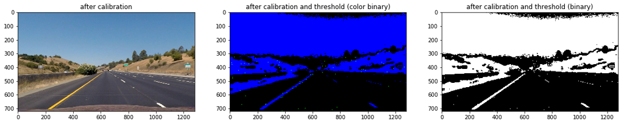

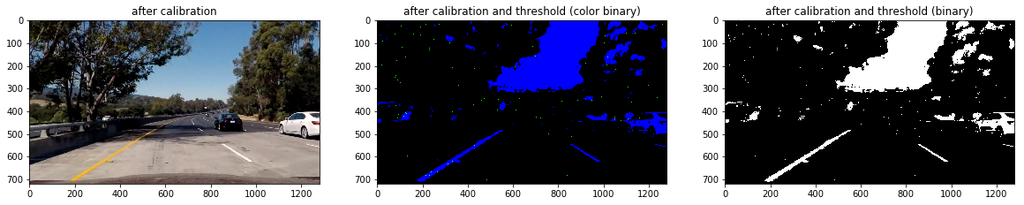

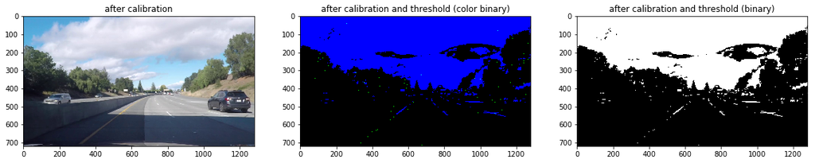

```python
# to see the binary image obtained by using the above pipeline for thresholding
count = 0
for fname in ['test_images/straight_lines1.jpg','test_images/test5.jpg', 'test_images/challenge_video_5000.jpg']:
# for fname in test_imgs: # use this instead if one wants to apply for all the images
    count += 1
    img = cv2.imread(fname)
    img = cv2.cvtColor(img, cv2.COLOR_BGR2RGB)
    undist = cv2.undistort(img, mtx, dist, None, mtx)
    color_binary_output =  pipeline_thresh(undist, color = True)
    binary_output =  pipeline_thresh(undist, color = False)

    fig=plt.figure(figsize=(20, 3.5))
    fig.add_subplot(1, 3, 1)
    plt.title('after calibration')
    plt.imshow(undist)
    fig.add_subplot(1, 3, 2)
    plt.title('after calibration and threshold (color binary)')
    plt.imshow(color_binary_output)
    fig.add_subplot(1, 3, 3)
    plt.title('after calibration and threshold (binary)')
    plt.imshow(binary_output, cmap = 'gray')
    # plt.savefig('output_images/threshold' + str(count) +'.png')
```

### 3.3. Perspective Transformation

Now we act the perspective transformation on the binary image obtained above. For this purpose, we compute the perspective transformation matrix **`M`** and its inverse **`Minv`**:

```python
# 4 corners of a source trapezoid
src = np.float32([[552,480], [732, 480], [1080, 700], [235,700]])
offset = 160
# 4 destination points
dst = np.float32([[offset, 0], [img_size[0]-offset, 0],
                        [img_size[0]-offset, img_size[1]], [offset, img_size[1]]])

# get the matrix for perspective transformation
M = cv2.getPerspectiveTransform(src, dst)
Minv = cv2.getPerspectiveTransform(dst, src) # for inverse
```

An example of the warped image obtained by acting the perspective transformation to a binary image is given below:

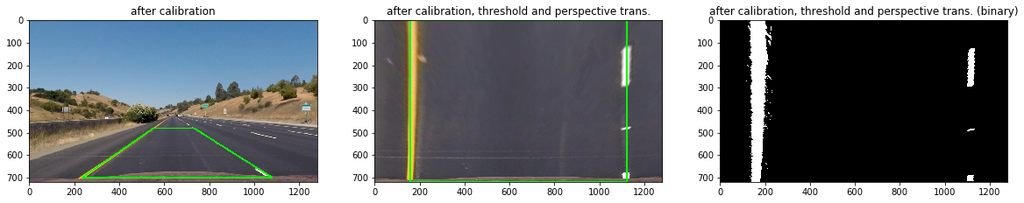

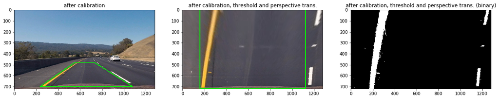

```python
# for displaying the warped images with detected inner edges
count = 0
for fname in ['test_images/straight_lines1.jpg', 'test_images/test3.jpg']:
# for fname in test_imgs: # use to show all the images
    count += 1
    img = cv2.imread(fname)
    img = cv2.cvtColor(img, cv2.COLOR_BGR2RGB)
    undist = cv2.undistort(img, mtx, dist, None, mtx)
    binary_output =  pipeline_thresh(undist, color = False)
    warped = cv2.warpPerspective(img, M, img_size, flags=cv2.INTER_LINEAR)
    binary_warped = cv2.warpPerspective(binary_output, M, img_size, flags=cv2.INTER_LINEAR)
    cv2.polylines(undist, [np.int_(src)], True, (0,255,0), thickness = 5)
    cv2.polylines(warped, [np.int_(dst)], True, (0,255,0), thickness = 5)

    fig=plt.figure(figsize=(20, 3.5))
    fig.add_subplot(1, 3, 1)
    plt.title('after calibration')
    plt.imshow(undist)
    fig.add_subplot(1, 3, 2)
    plt.title('after calibration, threshold and perspective trans.')
    plt.imshow(warped)
    fig.add_subplot(1, 3, 3)
    plt.title('after calibration, threshold and perspective trans. (binary)')
    plt.imshow(binary_warped, cmap = 'gray')
    # plt.savefig('output_images/perspective'+str(count)+'.png')
```

### 3.4. Lane Detection and Fitting + 3.5. Curvature of Lane and Deviation from Center

Now we use the binary image after the perspective transformation to detect the lanes. We will define the following functions:

- `lane_detect()`: this function detects the locations of the left and right lane lines in a warped binary image
- `curvature_dev_center()`: computes the curvature radii of the left and right lane lines (in meter) as well as the deviation of the vehicle from the center of the lane in the unit of meter.

The implementation goes as follows:

```python
# conversions in x and y from pixels space to meters
ym_per_pix = 30/720 # meters per pixel in y dimension
xm_per_pix = 3.7/700 # meters per pixel in x dimension

def lane_detect(binary_warped):
    """
    This function takes a warped binary image as an input
    and detect the locations of the lanes.

    """
    # create a color binary image
    out_img = np.dstack((binary_warped, binary_warped, binary_warped))*255

    # for check if detected
    detected = False

    # histogram of the bottom half of the image
    histogram = np.sum(binary_warped[binary_warped.shape[0]//2:,:], axis=0)
    # find the peak of the left and right halves of the histogram and
    # regard them as the starting points of the left and right lane lines
    midpoint = np.int(histogram.shape[0]//2)
    leftx_base = np.argmax(histogram[:midpoint])
    rightx_base = np.argmax(histogram[midpoint:]) + midpoint

    # number of sliding windows for lane detection
    nwindows = 9
    # height of windows
    window_height = np.int(binary_warped.shape[0]//nwindows)
    # width of the windows +/- margin
    # margin = 100
    margin = 100
    # minimum number of pixels found to recenter window
    minpix = 50
    # positions of all nonzero pixels in the image
    nonzero = binary_warped.nonzero()
    nonzeroy = np.array(nonzero[0]) # x coordinate
    nonzerox = np.array(nonzero[1]) # y coordinate
    # current positions to be updated for each window
    leftx_current = leftx_base
    rightx_current = rightx_base
    # list for storing left and right lane pixel indices
    left_lane_inds = []
    right_lane_inds = []

    # step through the windows one by one
    for window in range(nwindows):

        # identify window boundaries in x and y (and right and left)
        win_y_low = binary_warped.shape[0] - (window+1)*window_height
        win_y_high = binary_warped.shape[0] - window*window_height
        win_xleft_low = leftx_current - margin
        win_xleft_high = leftx_current + margin
        win_xright_low = rightx_current - margin
        win_xright_high = rightx_current + margin

        # NOTE: this part can be removed in case of not interested in the intermediate image.
        # draw the windows on the visualization image
        cv2.rectangle(out_img,(win_xleft_low,win_y_low),(win_xleft_high,win_y_high),(0,255,0), 2)
        cv2.rectangle(out_img,(win_xright_low,win_y_low),(win_xright_high,win_y_high),(0,255,0), 2)

        # identify the nonzero pixels inside the window
        good_left_inds = ((nonzeroy >= win_y_low) & (nonzeroy < win_y_high) &
                            (nonzerox >= win_xleft_low) &  (nonzerox < win_xleft_high)).nonzero()[0]
        good_right_inds = ((nonzeroy >= win_y_low) & (nonzeroy < win_y_high) &
                            (nonzerox >= win_xright_low) &  (nonzerox < win_xright_high)).nonzero()[0]
        # append these indices to the lists
        left_lane_inds.append(good_left_inds)
        right_lane_inds.append(good_right_inds)

        # if (# of nonzero pixels in the window)  > minpix pixels, recenter next window on their mean position
        if len(good_left_inds) > minpix:
            leftx_current = np.int(np.mean(nonzerox[good_left_inds]))
        if len(good_right_inds) > minpix:
            rightx_current = np.int(np.mean(nonzerox[good_right_inds]))

    # concatenate the arrays of indices
    left_lane_inds = np.concatenate(left_lane_inds)
    right_lane_inds = np.concatenate(right_lane_inds)

    # again, extract left and right line pixel positions
    leftx = nonzerox[left_lane_inds]
    lefty = nonzeroy[left_lane_inds]
    rightx = nonzerox[right_lane_inds]
    righty = nonzeroy[right_lane_inds]

    ploty = np.linspace(0, binary_warped.shape[0]-1, binary_warped.shape[0] )

    # update only when the candidate pixels for the lanes are found, otherwise,
    # return the same result as the previous time frame
    if((leftx.size != 0) & (lefty.size != 0) & (rightx.size != 0) & (righty.size != 0)):

        # fit with a second order polynomial
        left_fit = np.polyfit(lefty, leftx, 2)
        right_fit = np.polyfit(righty, rightx, 2)
        # generate x and y values for plotting
        left_fitx = left_fit[0]*ploty**2 + left_fit[1]*ploty + left_fit[2]
        right_fitx = right_fit[0]*ploty**2 + right_fit[1]*ploty + right_fit[2]

        # detected
        detected = True

        # NOTE: this part can be removed in case of not interested in the intermediate image
        # create an image to show the selection window
        window_img = np.zeros_like(out_img)
        # add left and right lanes to out_img
        out_img[nonzeroy[left_lane_inds], nonzerox[left_lane_inds]] = [255, 0, 0]
        out_img[nonzeroy[right_lane_inds], nonzerox[right_lane_inds]] = [0, 0, 255]
        # Generate a polygon to illustrate the search window area
        # And recast the x and y points into usable format for cv2.fillPoly()
        left_line_window1 = np.array([np.transpose(np.vstack([left_fitx-margin, ploty]))])
        left_line_window2 = np.array([np.flipud(np.transpose(np.vstack([left_fitx+margin, ploty])))])
        left_line_pts = np.hstack((left_line_window1, left_line_window2))
        right_line_window1 = np.array([np.transpose(np.vstack([right_fitx-margin, ploty]))])
        right_line_window2 = np.array([np.flipud(np.transpose(np.vstack([right_fitx+margin, ploty])))])
        right_line_pts = np.hstack((right_line_window1, right_line_window2))
        # add add windows to the output image
        cv2.fillPoly(window_img, np.int_([left_line_pts]), (0, 255, 0))
        cv2.fillPoly(window_img, np.int_([right_line_pts]), (0, 255, 0))
        cv2.addWeighted(out_img, 1, window_img, 0.3, 0)

    else:
        left_fitx = None
        right_fitx = None


    return detected, leftx, lefty, rightx, righty, left_fitx, right_fitx, ploty, out_img


def curvature_dev_center(leftx, lefty, rightx, righty, ploty):
    """
    this function computes the curvature radii of the lanes in the unit of meter.

    this function computes how many meters the vehicle deviates from the center of the lane
    (if the vehicle is on the left/right of middle of the lane, then a positive/negative value is returned)

    """
    y_eval = np.max(ploty)
    y_eval_m = y_eval*ym_per_pix # in meter

    # for later use we also fit with a second order polynomial (in the unit of meter)
    left_fit_cr = np.polyfit(lefty*ym_per_pix, leftx*xm_per_pix, 2)
    right_fit_cr = np.polyfit(righty*ym_per_pix, rightx*xm_per_pix, 2)

    # Calculate the new radii of curvature
    left_curverad = ((1 + (2*left_fit_cr[0]*y_eval_m + left_fit_cr[1])**2)**1.5) / np.absolute(2*left_fit_cr[0])
    right_curverad = ((1 + (2*right_fit_cr[0]*y_eval_m + right_fit_cr[1])**2)**1.5) / np.absolute(2*right_fit_cr[0])

    # find the mid point of the lane at the bottom of the image
    left_lane_p = left_fit_cr[0]*(y_eval_m)**2 + left_fit_cr[1]*(y_eval_m) + left_fit_cr[2]
    right_lane_p = right_fit_cr[0]*(y_eval_m)**2 + right_fit_cr[1]*(y_eval_m) + right_fit_cr[2]
    mid_lane_p = (left_lane_p + right_lane_p)/2.0
    # deviation from the center of the vehicle (located at the center of the image in x-direction)
    dev_c = mid_lane_p - xm_per_pix*img_size[0]/2.0

    return left_curverad, right_curverad, dev_c
```

Some example of the lanes detection can be seen below:

```
curvature radii, left: 4038.41 meter, right: 4261.44 meter
deviation from the center of lane, -0.02 meter
```

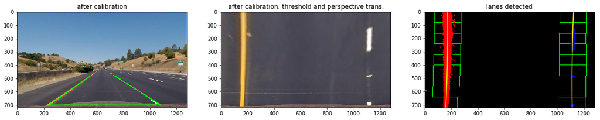

```
curvature radii, left: 2567.45 meter, right: 2318.96 meter
deviation from the center of lane, 0.16 meter
```

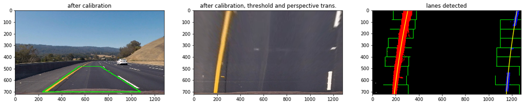

```python
# for displaying the warped images with detected inner edges
count = 0
for fname in ['test_images/straight_lines1.jpg', 'test_images/test3.jpg']:
# for fname in test_imgs: # show all the images
    count += 1
    img = cv2.imread(fname)
    img = cv2.cvtColor(img, cv2.COLOR_BGR2RGB)
    undist = cv2.undistort(img, mtx, dist, None, mtx)
    binary_output =  pipeline_thresh(undist, color = False)
    warped = cv2.warpPerspective(img, M, img_size, flags=cv2.INTER_LINEAR)
    binary_warped = cv2.warpPerspective(binary_output, M, img_size, flags=cv2.INTER_LINEAR)
    detected, leftx, lefty, rightx, righty, left_fitx, right_fitx, ploty, out_img=lane_detect(binary_warped)

    left_curverad, right_curverad, dev_c= curvature_dev_center(leftx, lefty, rightx, righty, ploty)
    print('curvature radii, left: {:.2f} meter, right: {:.2f} meter'.format(left_curverad, right_curverad))
    print('deviation from the center of lane, {:.2f} meter'.format(dev_c))
    cv2.polylines(undist, [np.int_(src)], True, (0,255,0), thickness = 5)

    fig=plt.figure(figsize=(20, 3.5))
    fig.add_subplot(1, 3, 1)
    plt.title('after calibration')
    plt.imshow(undist)
    fig.add_subplot(1, 3, 2)
    plt.title('after calibration, threshold and perspective trans.')
    plt.imshow(warped)
    fig.add_subplot(1, 3, 3)
    plt.title('lanes detected')
    plt.xlim(0, 1280)
    plt.ylim(720, 0)
    plt.imshow(out_img)
    plt.plot(left_fitx, ploty, color='yellow')
    plt.plot(right_fitx, ploty, color='yellow')
    # plt.savefig('output_images/lane_boundary' +str(count) + '.png')
    plt.show()
```

### 3.6. Inverse Perspective Transformation (Undistorted Image with Detected Lane)

Once the lane boundaries are detected, all we need to do is to map it back by the inverse perspective transformation and then combined with the color image of the road after the distortion corection. In this part, we combine this with the results above for generating a visualization with the detected lane. For this purpose we define two functions:

- `lane_visualization()`: this function creates an undistorted image with the detected lane added:
- `add_text()`: this function adds to an image the value of the curvature radius of the lane (which is computed as the average of the curvature radii of the left and right lanes) and the deviation of the vehicle from the center of the lane.

The implementation is as follows:

```python
def lane_visualization(binary_warped, left_fitx, right_fitx, ploty, Minv, undist):
    """
    this function creates an image with the detected lane displayed
    """
    warp_zero = np.zeros_like(binary_warped).astype(np.uint8)
    color_warp = np.dstack((warp_zero, warp_zero, warp_zero))

    # Recast the x and y points into usable format for cv2.fillPoly()
    pts_left = np.array([np.transpose(np.vstack([left_fitx, ploty]))])
    pts_right = np.array([np.flipud(np.transpose(np.vstack([right_fitx, ploty])))])
    pts = np.hstack((pts_left, pts_right))

    # draw the lane onto the warped blank image
    cv2.fillPoly(color_warp, np.int_([pts]), (0,255,0))
    cv2.polylines(color_warp, np.int_([pts_left]), False, (255,0,0), thickness = 20)
    cv2.polylines(color_warp, np.int_([pts_right]), False, (0,0,255), thickness = 20)

    # warp the blank back to original image space using inverse perspective matrix (Minv)
    newwarp = cv2.warpPerspective(color_warp, Minv, (img.shape[1], img.shape[0]))
    # Combine the result with the original image
    lane_vis = cv2.addWeighted(undist, 1, newwarp, 0.6, 0)

    return lane_vis

def add_text(img, curverad, dev_c):
    """
    This function is used for adding text on the image
    """

    with_text = cv2.putText(img, 'Radius of Curvature = {:.0f} (m)'.format(curverad),
                               org = (50, 50), fontFace = cv2.FONT_HERSHEY_SIMPLEX, fontScale = 2,
                                color = (255,255,255), thickness = 4)
    with_text = cv2.putText(with_text, 'Vehicle is {:.2f}m left of center'.format(dev_c),
                               org = (50, 110), fontFace = cv2.FONT_HERSHEY_SIMPLEX, fontScale = 2,
                                color = (255,255,255), thickness = 4)

    return with_text
```

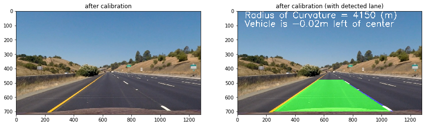

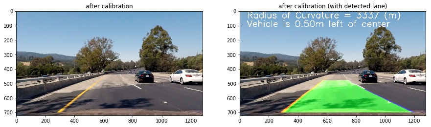

```python
# to show final output image
count = 0
for fname in ['test_images/straight_lines1.jpg', 'test_images/test4.jpg']:
# for fname in test_imgs: # to show all images
    count += 1
    img = cv2.imread(fname)
    img = cv2.cvtColor(img, cv2.COLOR_BGR2RGB)
    undist = cv2.undistort(img, mtx, dist, None, mtx)
    binary_output =  pipeline_thresh(undist, color = False)
    warped = cv2.warpPerspective(img, M, img_size, flags=cv2.INTER_LINEAR)
    binary_warped = cv2.warpPerspective(binary_output, M, img_size, flags=cv2.INTER_LINEAR)
    detected, leftx, lefty, rightx, righty, left_fitx, right_fitx, ploty, out_img=lane_detect(binary_warped)
    lane_vis = lane_visualization(binary_warped, left_fitx, right_fitx, ploty, Minv, undist)
    left_curverad, right_curverad, dev_c = curvature_dev_center(leftx, lefty, rightx, righty, ploty)
    # compute the curvature radius of the lane as the average of the curvature radii for left and right lanes
    curverad = (left_curverad + right_curverad)/2.0
    result = add_text(lane_vis, curverad, dev_c)

    fig=plt.figure(figsize=(15, 4))
    fig.add_subplot(1, 2, 1)
    plt.title('after calibration')
    plt.imshow(undist)
    fig.add_subplot(1, 2, 2)
    plt.title('after calibration (with detected lane)')
    plt.imshow(result)
    # plt.savefig('output_images/final'+str(count) + '.png')
    plt.show()
```

### 3.7 Pipeline for Image

By using the above results, we define a function pipeline_image() which processes an image (in BGR) and returns a image with a detected lane plus some information such as the curvature radius of the lane and the deviation of the vehicle from the center:

```python
def pipeline_image(image):
    """
    INPUT
    image: image in BGR
    # mtx: Calibration matrix
    # dist: distortion coefficients
    # M: matrix for perspective transformation
    # Minv: matrix for inverse perspective transformation

    """
    # for a given image: img in BGR, convert to RGB
    img = cv2.cvtColor(image, cv2.COLOR_BGR2RGB)
    # undistort the image
    undist = cv2.undistort(img, mtx, dist, None, mtx)
    # return a binary image derived by using gradient and color thresholds
    binary_output =  pipeline_thresh(undist, color = False)
    #warped = cv2.warpPerspective(img, M, img_size, flags=cv2.INTER_LINEAR)
    # apply perspective transformation to the binary image
    binary_warped = cv2.warpPerspective(binary_output, M, img_size, flags=cv2.INTER_LINEAR)
    # lane detection and computation of curvature radius and deviation from center of lane
    detected, leftx, lefty, rightx, righty, left_fitx, right_fitx, ploty, out_img=lane_detect(binary_warped)
    # inverse perspective transformation and visualize the lane
    lane_vis = lane_visualization(binary_warped, left_fitx, right_fitx, ploty, Minv, undist)
    # compute the curvature radius of the lane as the average of the curvature radii for left and right lanes, and
    # add to the image information of the curvature radius and deviation from the center of lane
    left_curverad, right_curverad, dev_c = curvature_dev_center(leftx, lefty, rightx, righty, ploty)
    curverad = (left_curverad + right_curverad)/2.0
    result = add_text(lane_vis, curverad, dev_c)

    return result
```

```python
# ### In case one wants to check the above pipeline works for the images, use the code below
# for fname in test_imgs:
#     img = cv2.imread(fname)
#     result = pipeline_image(img)

#     plt.title('after calibration (with detected lane)')
#     plt.imshow(result)
#     plt.show()
```

### 3.8. Pipeline for Video: Extra/Modification

Now we apply the above approach to detec the lane in the videos. To do this, we first introduce class `Line` to store some history of the detected lanes:

```python
# Define a class to receive the characteristics of each line detection
class Line():
    def __init__(self):
        # was the line detected in the last iteration?
        self.detected = False
        # x values of the last n fits of the line
        self.recent_xfitted = []
        #average x values of the fitted line over the last n iterations
        self.bestx = None
        #polynomial coefficients averaged over the last n iterations
        self.best_fit = None
        #polynomial coefficients for the most recent fit
        self.current_fit = np.array([0,0,0], dtype='float')
        #radius of curvature of the line in some units
        self.radius_of_curvature = None
        #distance in meters of vehicle center from the line
        self.line_base_pos = None
        #difference in fit coefficients between last and new fits
        self.diffs = np.array([0,0,0], dtype='float')
        #x values for detected line pixels
        self.allx = None
        #y values for detected line pixels
        self.ally = None
```

We also introduce the function `lane_detect_update()` which, after detecting the lane lines once, can detect the lane lines faster than `lane_detect()` defined above. The main point of `lane_detect_update()` is that once the lane is detected in the previous time frame, then use the location of the detected lane in the previous time frame as the starting point and then do the window search of the lane at the time frame.

```python
def lane_detect_update(binary_warped, leftx, lefty, rightx, righty):
    """
    After the lane is detected at a given instance, then one can
    use this function to detect the lane in the next instance by using
    the left_fit and right_fit in the previous instance as inputs

    """
    # create an image to draw on
    out_img = np.dstack((binary_warped, binary_warped, binary_warped))*255

    # list positions of pixels with nonzero value
    nonzero = binary_warped.nonzero()
    nonzeroy = np.array(nonzero[0])
    nonzerox = np.array(nonzero[1])
    # margin = 100
    margin = 30

    # check if the update is done or not
    update = False

    # fit with a second order polynomial (in the unit of pixel)
    left_fit = np.polyfit(lefty, leftx, 2)
    right_fit = np.polyfit(righty, rightx, 2)
    ploty = np.linspace(0, binary_warped.shape[0]-1, binary_warped.shape[0] )
    left_fitx = left_fit[0]*ploty**2 + left_fit[1]*ploty + left_fit[2]
    right_fitx = right_fit[0]*ploty**2 + right_fit[1]*ploty + right_fit[2]

    left_lane_inds = ((nonzerox > (left_fit[0]*(nonzeroy**2) + left_fit[1]*nonzeroy +
                        left_fit[2] - margin)) & (nonzerox < (left_fit[0]*(nonzeroy**2) +
                                    left_fit[1]*nonzeroy + left_fit[2] + margin)))
    right_lane_inds = ((nonzerox > (right_fit[0]*(nonzeroy**2) + right_fit[1]*nonzeroy +
                        right_fit[2] - margin)) & (nonzerox < (right_fit[0]*(nonzeroy**2) +
                            right_fit[1]*nonzeroy + right_fit[2] + margin)))

    # again, extract left and right line pixel positions
    leftx_update = nonzerox[left_lane_inds]
    lefty_update = nonzeroy[left_lane_inds]
    rightx_update = nonzerox[right_lane_inds]
    righty_update = nonzeroy[right_lane_inds]

    # update only when the candidate pixels for the lanes are found, otherwise,
    # return the same result as the previous time frame
    if((leftx_update.size != 0) & (lefty_update.size != 0) & (rightx_update.size != 0) & (righty_update.size != 0)):

        leftx = leftx_update
        lefty = lefty_update
        rightx = rightx_update
        righty = righty_update

        # fit with a second order polynomial
        left_fit = np.polyfit(lefty, leftx, 2)
        right_fit = np.polyfit(righty, rightx, 2)
        # generate x and y values for plotting
        # ploty = np.linspace(0, binary_warped.shape[0]-1, binary_warped.shape[0] )
        left_fitx = left_fit[0]*ploty**2 + left_fit[1]*ploty + left_fit[2]
        right_fitx = right_fit[0]*ploty**2 + right_fit[1]*ploty + right_fit[2]

        # updated
        update = True

        # NOTE: this part can be removed in case of not interested in the intermediate image
        # create an image to show the selection window
        window_img = np.zeros_like(out_img)
        # add left and right lanes to out_img
        out_img[nonzeroy[left_lane_inds], nonzerox[left_lane_inds]] = [255, 0, 0]
        out_img[nonzeroy[right_lane_inds], nonzerox[right_lane_inds]] = [0, 0, 255]
        # Generate a polygon to illustrate the search window area
        # And recast the x and y points into usable format for cv2.fillPoly()
        left_line_window1 = np.array([np.transpose(np.vstack([left_fitx-margin, ploty]))])
        left_line_window2 = np.array([np.flipud(np.transpose(np.vstack([left_fitx+margin, ploty])))])
        left_line_pts = np.hstack((left_line_window1, left_line_window2))
        right_line_window1 = np.array([np.transpose(np.vstack([right_fitx-margin, ploty]))])
        right_line_window2 = np.array([np.flipud(np.transpose(np.vstack([right_fitx+margin, ploty])))])
        right_line_pts = np.hstack((right_line_window1, right_line_window2))
        # add add windows to the output image
        cv2.fillPoly(window_img, np.int_([left_line_pts]), (0, 255, 0))
        cv2.fillPoly(window_img, np.int_([right_line_pts]), (0, 255, 0))
        cv2.addWeighted(out_img, 1, window_img, 0.3, 0)

    return update, leftx, lefty, rightx, righty, left_fitx, right_fitx, ploty, out_img
```

By using this, the function `pipeline_video()` for the pipeline for the lane detection at each time in a video is as follows:

```python
def pipeline_video(image):
    """
    INPUT
    image: image in BGR
    # mtx: Calibration matrix
    # dist: distortion coefficients
    # M: matrix for perspective transformation
    # Minv: matrix for inverse perspective transformation

    """
    img = image
    # undistort the image
    undist = cv2.undistort(img, mtx, dist, None, mtx)
    # return a binary image derived by using gradient and color thresholds
    binary_output =  pipeline_thresh(undist, color = False)
    # apply perspective transformation to the binary image
    binary_warped = cv2.warpPerspective(binary_output, M, img_size, flags=cv2.INTER_LINEAR)

    if left_lane.detected == False: # in case the lane has not been detected before
        detected, leftx, lefty, rightx, righty, left_fitx, right_fitx, ploty, out_img = lane_detect(binary_warped)
        left_lane.detected = detected # if detected or not is stored in left_lane... for convenience
    else: # in case the lane has been saved in the previous time frame, use the fast detection method
        leftx = left_lane.allx
        lefty = left_lane.ally
        rightx = right_lane.allx
        righty = right_lane.ally
        update, leftx, lefty, rightx, righty, left_fitx, right_fitx, ploty, out_img = lane_detect_update(binary_warped, leftx, lefty, rightx, righty)
        left_lane.detected = update

    if((leftx.size == 0) | (lefty.size == 0) | (rightx.size == 0) | (righty.size == 0)): # in case failed to detect
        leftx = left_lane.allx
        lefty = left_lane.ally
        rightx = right_lane.allx
        righty = right_lane.ally
        left_fitx = left_lane.bestx
        right_fitx = right_lane.bestx
        left_lane.detected = False
    elif((left_lane.radius_of_curvature !=None) & (left_lane.line_base_pos !=None)) :
        # even when detected, if the curvature radius of the detected lane or/and the deviation
        # of the location of the vehicle from the center of the detected lane are very different from
        # those in the previous time frame, then do not update the detected lane info.
        left_curverad, right_curverad, dev_c = curvature_dev_center(leftx, lefty, rightx, righty, ploty)
        curverad = (left_curverad + right_curverad)/2.0
        if((abs(left_lane.radius_of_curvature - curverad) > 1.5*left_lane.radius_of_curvature) |
              (abs(left_lane.line_base_pos - dev_c) > 0.3)):
            leftx = left_lane.allx
            lefty = left_lane.ally
            rightx = right_lane.allx
            righty = right_lane.ally
            left_fitx = left_lane.bestx
            right_fitx = right_lane.bestx
            left_lane.detected = False

    # update the stored information
    left_lane.allx = leftx
    left_lane.ally = lefty
    right_lane.allx = rightx
    right_lane.ally = righty

    if len(left_lane.recent_xfitted) < 20: # in case the memory is not full
        left_lane.recent_xfitted.append(left_fitx)
        right_lane.recent_xfitted.append(right_fitx)
    else: # in case the memory is full
        left_temp = left_lane.recent_xfitted[1:]
        left_lane.recent_xfitted = left_temp
        left_lane.recent_xfitted.append(left_fitx)
        right_temp = right_lane.recent_xfitted[1:]
        right_lane.recent_xfitted = right_temp
        right_lane.recent_xfitted.append(right_fitx)

    # average over past records to determine fitted positions of the lanes
    left_lane.bestx = np.zeros_like(left_fitx)
    right_lane.bestx = np.zeros_like(right_fitx)
    for i in range(len(left_lane.recent_xfitted)):
        left_lane.bestx += left_lane.recent_xfitted[i]
        right_lane.bestx += right_lane.recent_xfitted[i]
    left_lane.bestx = left_lane.bestx / float(len(left_lane.recent_xfitted))
    right_lane.bestx = right_lane.bestx / float(len(right_lane.recent_xfitted))
    left_fitx = left_lane.bestx
    right_fitx = right_lane.bestx

    # add to the image information of the curvature radius and deviation from the center of lane
    left_curverad, right_curverad, dev_c = curvature_dev_center(leftx, lefty, rightx, righty, ploty)
    curverad = (left_curverad + right_curverad)/2.0
    # the curvature of the lane and the deviation are stored in the left_lane... for convenience.
    left_lane.radius_of_curvature = (left_curverad + right_curverad)/2.0
    left_lane.line_base_pos = dev_c
    # inverse perspective transformation and visualize the lane
    lane_vis = lane_visualization(binary_warped, left_fitx, right_fitx, ploty, Minv, undist)
    result = add_text(lane_vis, curverad, dev_c)

    return result
```

## 4. Performance

By using this pipeline, the lane detection for a whole video is implemented as follows:

```python
vname = 'videos/project_video.mp4'
video = VideoFileClip(vname)
left_lane = Line()
right_lane = Line()
output = video.fl_image(pipeline_video)
output.write_videofile('videos/project_output.mp4', audio=False)
```

```
[MoviePy] >>>> Building video videos/project_output.mp4
[MoviePy] Writing video videos/project_output.mp4
```

```
[MoviePy] Done.
[MoviePy] >>>> Video ready: videos/project_output.mp4
```

Here we also carry out the lane detection for the optional video:

```python
vname = 'videos/challenge_video.mp4'
video = VideoFileClip(vname)
left_lane = Line()
right_lane = Line()
output = video.fl_image(pipeline_video)
# output = video.fl_image(pipeline_video).subclip(0, 2) # use this when one wants to apply a part of the video
output.write_videofile('videos/challenge_output.mp4', audio=False)
```

```
[MoviePy] >>>> Building video videos/challenge_output.mp4
[MoviePy] Writing video videos/challenge_output.mp4
```

```
[MoviePy] Done.
[MoviePy] >>>> Video ready: videos/challenge_output.mp4
```

## Appendix

The following code can be used to capture an image at a given time frame from a video.

```python
# video_name = 'challenge_video.mp4'
# time_to_capture = 1500 # note that 1.5 second is denoted as 1500
# image_name = video_name[:-4] + "_" + str(time_to_capture) + '.jpg'
# v_cap = cv2.VideoCapture(video_name)
# v_cap.set(cv2.CAP_PROP_POS_MSEC,1500)
# success, img = v_cap.read()
# if success:
#     cv2.imwrite(image_name, img)
```